# R on the Command Line

Laurie Stevison

# Getting Started

*If you are using this code with the video, note that some slides have been added post-recording and are not shown. See 4.05.walkthrough.R in the compressed data tarball for the code from the recording.*

So far we’ve treated R as separate from linux, but you can execute R from the [command line](https://en.wikipedia.org/wiki/Command-line_interface). This is the focus of this tutorial.

Normally we would make an R Notebook, but since we are planning to use this script on the CL, start an RScript in RStudio. We will work with a different subset of the depth data from Activity #1.

You will also want to copy the data files into this folder to follow along, even if you load our data object.

# Set up workspace

- You are working within an R Project (check in the top right corner of RStudio - you should see the project name “R_Mini_Course”).
- This means that the project directory will also be set as working directory.
- You should be saving your R Script in the R Project and using `/modules/Module_7/` to point at the current module directory.
- Before starting, it may be helpful to have a chunk of code that does the following:
  - clear your workspace `rm(list=ls())`
  - load your packages `library(<package-name>)`
  - check your session information `sessionInfo()`
  - list files in your working directory `list.files(getwd())`

# Read in datasets

You will need to add path information to the `raw_data` directory once you have uncompressed the data tarball.

```r
#samtools.depth=read.table(file="chrX.depth.out")
#View(samtools.depth)
```

You may also read in the previously made object:

```r
samtools.depth <- readRDS(file = "../../data/chrX.depth.out.rds")
head(samtools.depth, 3)
```

```
##              V1 V2 V3
## 1 chrXL_group3b  1  1
## 2 chrXL_group3b  2  3
## 3 chrXL_group3b  3  4
```

# Integrating R with the command line

To use R on the command line, we are going to return to a script you wrote when we first started using R. You could copy the script `coverage.R` from Activity #1 to this directory or the code from it into a new script.

Feel free to clean up the bits in the middle, Remember, we made a copy - you ALWAYS have the original!

### Revisiting our depth plot

Let’s recreate the plot we made in Activity #1.

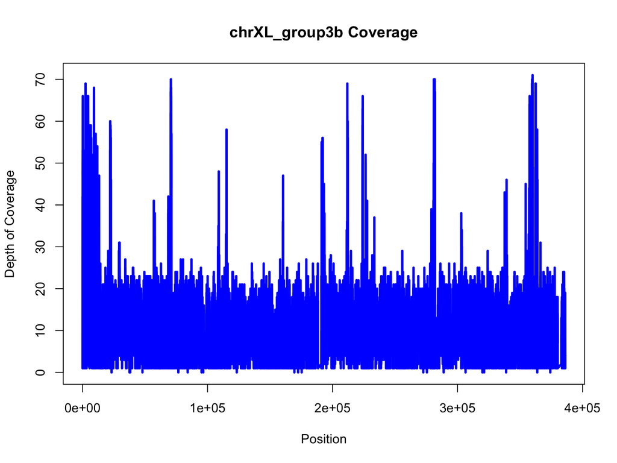

```r
chrXL_group3b=subset(samtools.depth,V1=="chrXL_group3b")
plot(chrXL_group3b$V2,chrXL_group3b$V3,xlab="Position",ylab="Depth of Coverage",main="chrXL_group3b Coverage",type="l",lwd=3,col="blue")
```

That was still a really messy plot. Let’s make some modifications to improve this figure. First, let’s convert the x axis into megabases.

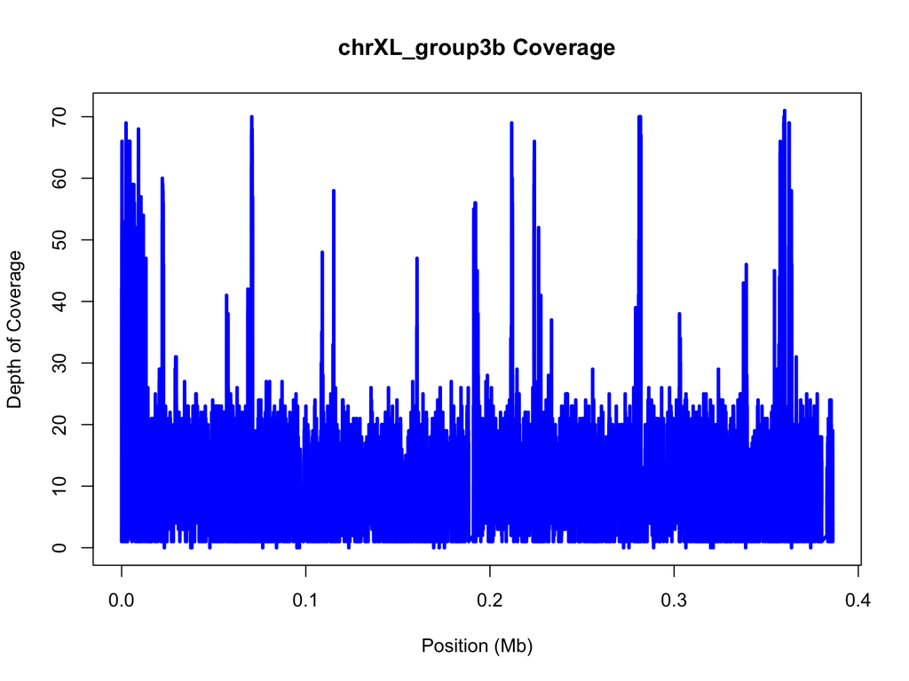

```r
mb=chrXL_group3b$V2/10^6
plot(mb,chrXL_group3b$V3,xlab="Position (Mb)",ylab="Depth of Coverage",main="chrXL_group3b Coverage",type="l",lwd=3,col="blue")
```

Notice, we’ve change the x in our plot function and the label for the x-axis to specify that it is in megabases (Mb) for short.

# Other Modifications

Now, let’s add in some bells and whistles that we’ve learned since Activity #1.

We’ll add an abline for the mean and some text stating the mean as well.

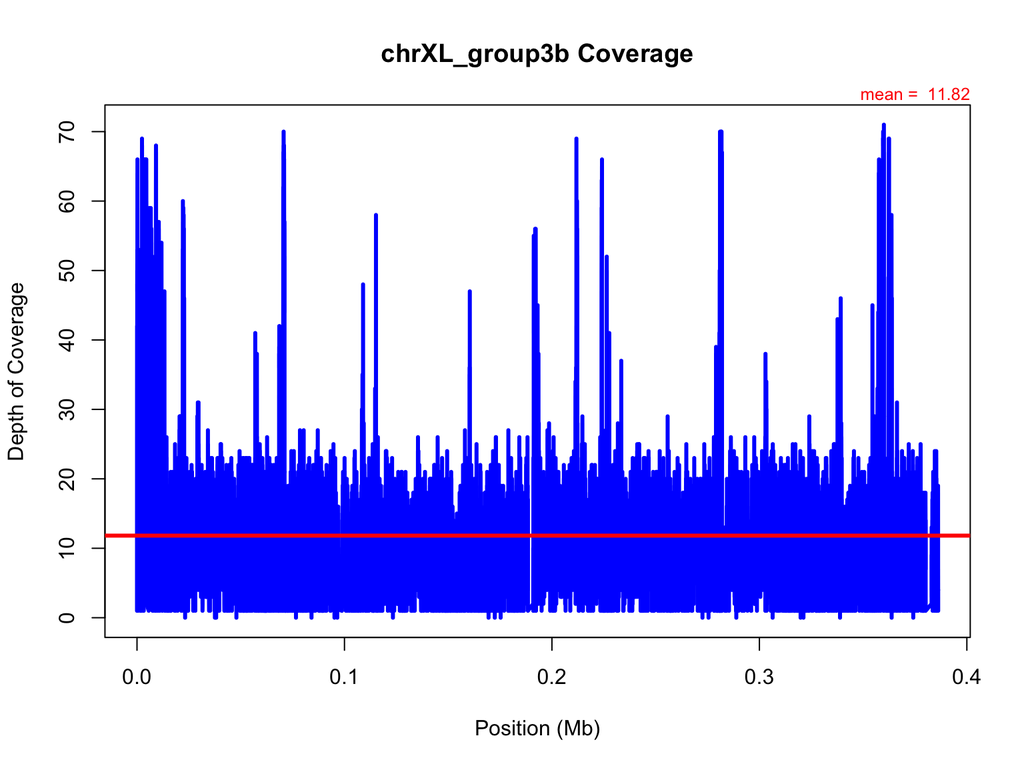

```r
plot(mb,chrXL_group3b$V3,xlab="Position (Mb)",ylab="Depth of Coverage",main="chrXL_group3b Coverage",type="l",lwd=3,col="blue")

#add an abline
avg=mean(chrXL_group3b$V3)
abline(h=avg,col="red",lwd=3)

#add text with mean
mtext(side=3,paste("mean = ",round(avg,2)),cex=0.8,col="red",adj=1)
```

# Independently, try again but write to a file this time.

Here, we will write the file to a png instead of a PDF. As some of you have noticed, a PDF writes the data as vector graphics and thus the file size is large and takes a long time to load. A png will rasterize the image, reducing the file size and load time.

Fill in the code to generate the plot where indicated:

```r
#write plot to a file
png(file="chrXL_group3b.png",res=600,height=2.75,width=4.5,units="in",pointsize=7)

# Add the code to generate the previous plot

#turn off plotting device
dev.off()
```

Remember, because we wrote this to a file, we need to open the file to see the image. It will not render in your notebook this time.

# Play with some of these png paramters (res, height/width, and pointsize) to see how it changes the output file

# Smoothing

Another thing we can do is smooth the data. One of the better smoothing functions in R is `loess`.

```r
lo=loess(chrXL_group3b$V3~chrXL_group3b$V2,span=0.01,data.frame(x=chrXL_group3b$V2,y=chrXL_group3b$V3))
```

This function will take ~1-2 minutes to run depending on your OS.

`span=0.01` is a 1% smoothing span, which seems very low, but we have LOTS of data so any value larger would take a VERY long time.

```r
length(chrXL_group3b$V2)
```

```
## [1] 334023
```

```r
length(chrXL_group3b$V2)*0.01
```

```
## [1] 3340.23
```

```r
length(chrXL_group3b$V2)*0.001
```

```
## [1] 334.023
```

We can also smooth using `enp.target`; This is more useful if smoothing over different size datasets. It uses a precise number rather than a percentage.

```r
lo=loess(chrXL_group3b$V3~chrXL_group3b$V2,enp.target=tail(chrXL_group3b$V2,1)/500,data.frame(x=chrXL_group3b$V2,y=chrXL_group3b$V3))
```

# What does the enp.target look like?

```r
tail(chrXL_group3b$V2,1)
```

```
## [1] 386180
```

```r
tail(chrXL_group3b$V2,1)/500
```

```
## [1] 772.36
```

# `span` versus `enp.target`

Here, we will compare how `span` and `enp.target` differ when you are comparing two chromosomes. As we’ve done before, we will start with a blank plot and add each piece in one at a time.

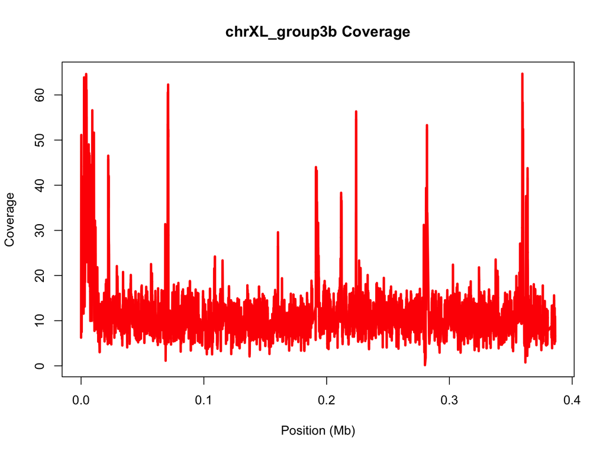

```r
lo1=loess(chrXL_group3b$V3~chrXL_group3b$V2,span=0.001,data.frame(x=chrXL_group3b$V2,y=chrXL_group3b$V3))

plot(mb,chrXL_group3b$V3,ylim=range(predict(lo1)),main="chrXL_group3b Coverage",xlab="Position (Mb)",ylab="Coverage",type="n")

#add loess prediction
lines(mb,predict(lo1),lwd=3,col="red")
```

Now, try to repeat the process with the other chromosome. Go back to your code and subset for chrXR_group3a

```r
#chrXR_group3a=
```

Continue to the next slide for the solution.

Solution:

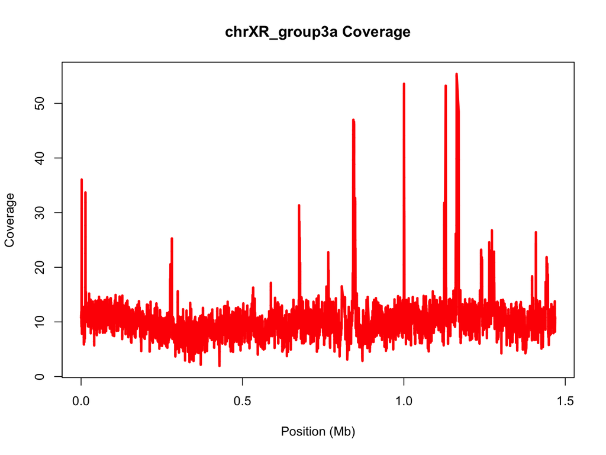

```r
chrXR_group3a=subset(samtools.depth,samtools.depth$V1=="chrXR_group3a")
mb2=chrXR_group3a$V2/10^6

#Perform loess for a much longer chromosome:
lo2=loess(chrXR_group3a$V3~chrXR_group3a$V2,span=0.001,data.frame(x=chrXR_group3a$V2,y=chrXR_group3a$V3))

plot(mb2,chrXR_group3a$V3,ylim=range(predict(lo2)),main="chrXR_group3a Coverage",xlab="Position (Mb)",ylab="Coverage",type="n")

#add loess prediction
lines(mb2,predict(lo2),lwd=3,col="red")
```

Let’s compare the range of data with and without smoothing:

```r
#range of data without smoothing
cat("chrXL_group3b\n")
```

```
## chrXL_group3b
```

```r
summary(chrXL_group3b$V3)
```

```
##    Min. 1st Qu.  Median    Mean 3rd Qu.    Max.
##    0.00    8.00   11.00   11.82   14.00   71.00
```

```r
cat("chrXL_group3a\n")
```

```
## chrXL_group3a
```

```r
summary(chrXR_group3a$V3)
```

```
##    Min. 1st Qu.  Median    Mean 3rd Qu.    Max.
##    0.00    7.00   10.00   10.44   13.00   70.00
```

```r
#range of smoothed data
cat("chrXL_group3b\n")
```

```
## chrXL_group3b
```

```r
summary(predict(lo1))
```

```
##    Min. 1st Qu.  Median    Mean 3rd Qu.    Max.
##  0.1497  8.7432 10.7693 11.8515 12.9247 64.6999
```

```r
cat("chrXL_group3a\n")
```

```
## chrXL_group3a
```

```r
summary(predict(lo2))
```

```
##    Min. 1st Qu.  Median    Mean 3rd Qu.    Max.
##   1.939   8.643  10.173  10.447  11.558  55.399
```

Using span, we are smoothing over a different number of parameters for the two datasets based on their size. This makes it hard to compare from chromosome to chromosome. `enp.target` is preferred method for chromosomes so they can be compared.

```r
lo3=loess(chrXR_group3a$V3~chrXR_group3a$V2,
          enp.target = tail(chrXR_group3a$V2,1)/500,
          data.frame(x=chrXR_group3a$V2,y=chrXR_group3a$V3))
```

```r
#range of data without smoothing
cat("chrXL_group3b\n")
```

```
## chrXL_group3b
```

```r
summary(chrXL_group3b$V3)
```

```
##    Min. 1st Qu.  Median    Mean 3rd Qu.    Max.
##    0.00    8.00   11.00   11.82   14.00   71.00
```

```r
cat("chrXL_group3a\n")
```

```
## chrXL_group3a
```

```r
summary(chrXR_group3a$V3)
```

```
##    Min. 1st Qu.  Median    Mean 3rd Qu.    Max.
##    0.00    7.00   10.00   10.44   13.00   70.00
```

```r
#range of smoothed data
cat("chrXL_group3b\n")
```

```
## chrXL_group3b
```

```r
summary(predict(lo))
```

```
##    Min. 1st Qu.  Median    Mean 3rd Qu.    Max.
##   3.258   9.495  10.790  11.828  12.158  54.154
```

```r
cat("chrXL_group3a\n")
```

```
## chrXL_group3a
```

```r
summary(predict(lo3))
```

```
##    Min. 1st Qu.  Median    Mean 3rd Qu.    Max.
##   2.626   8.729  10.169  10.448  11.472  52.104
```

# Integrate smoothed data with previous plot

Let’s add this smoothed data on top of the raw data. Make the appropriate modifications to the code to write the plot to a file.

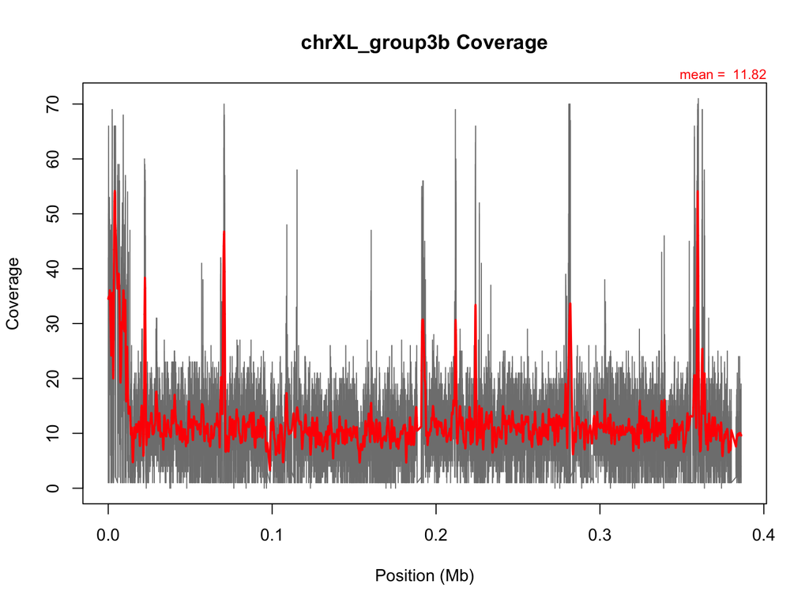

```r
## Let's see our new plot.
plot(mb,chrXL_group3b$V3,main="chrXL_group3b Coverage",xlab="Position (Mb)",ylab="Coverage",type="l",col="grey50")

#only text of mean needed, not abline, because smoothed function is better!
mtext(side=3,paste("mean = ",round(avg,2)),cex=0.8,col="red",adj=1)
lines(mb,predict(lo),lwd=2,col="red")
```

# Scaling up:

This is a nice script, but this is only the coverage along a single contig for our dataset.

We have 13 contigs and would like to see how coverage looks across ALL contigs. This is a bit much for our local machine to do.

To run this R script on the ASC, we will need to transfer it up to the machine and write a shell script to change the name of the chromosome each time.

In Activity #3 you can practice using R on the CL You will execute the script for 1 contig only first to test the script works on an HPC.

An easy way to execute an R script on the command line:

`R --vanilla <coverage.R`

If you decide not to perform Activity #3 or you do not have access to HPC:

Congratulations, you’ve completed this mini course!